# Eksamen

# I created a table that would count each recipient from each year. By using the “elephant_without_denmark” table I can get an idea of the number of foreign recipients each year.

```r
elephant_sum_foreign <- elephant_without_denmark %>% count(year_received_the_Order_of_the_Elephant, sort = TRUE)
```

# Creating a line graph that shows international recipients each year and defining the y axes’ border.

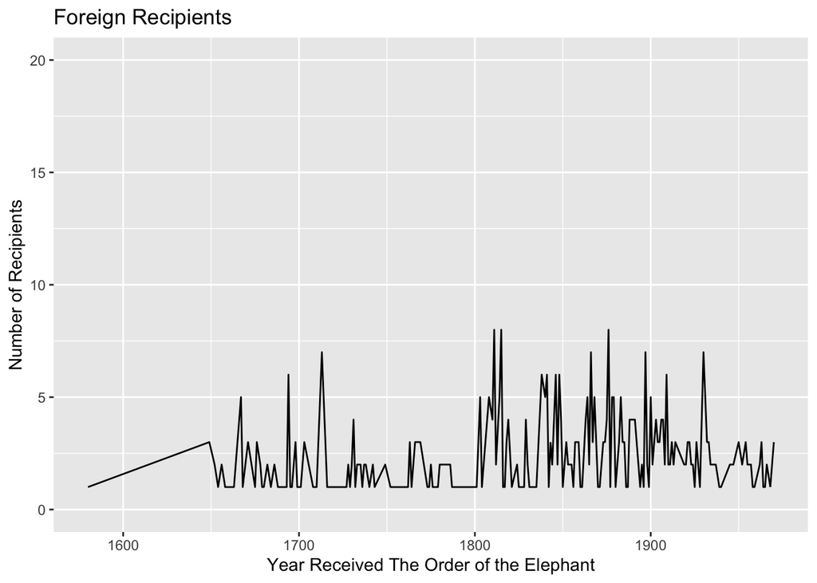

```r
ggplot(data = elephant_sum_foreign) +
  geom_line(mapping = aes(x = year_received_the_Order_of_the_Elephant, y = n)) +
ylim(0, 20) + ggtitle("Foreign Recipients") + xlab("Year Received The Order of the Elephant") + ylab("Number of Recipients")
```

# Overlaping the two previosly created graphs, in order to get an idea of the diplomatic tendencies over time. Defining the limit of the y axes and the names of the graph.

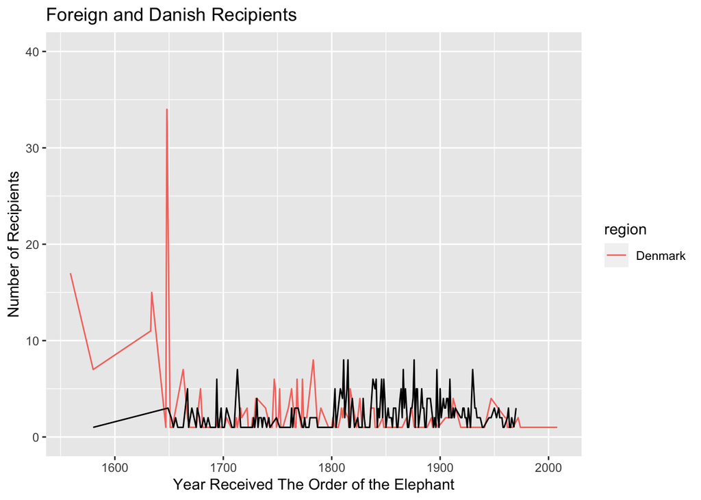

```r
ggplot () +
  geom_line(data = elephant_only_denmark, mapping = aes (x = year_received_the_Order_of_the_Elephant, y = n, color = region)) +
  geom_line(data = elephant_sum_foreign, mapping = aes(x = year_received_the_Order_of_the_Elephant, y = n)) +
  ylim(0, 40) + ggtitle("Foreign and Danish Recipients") + xlab("Year Received The Order of the Elephant") + ylab("Number of Recipients")
```

# Using “geom_smooth” on the two graphs to created the same graph as above. However the smooth graph is easier to comprehend.

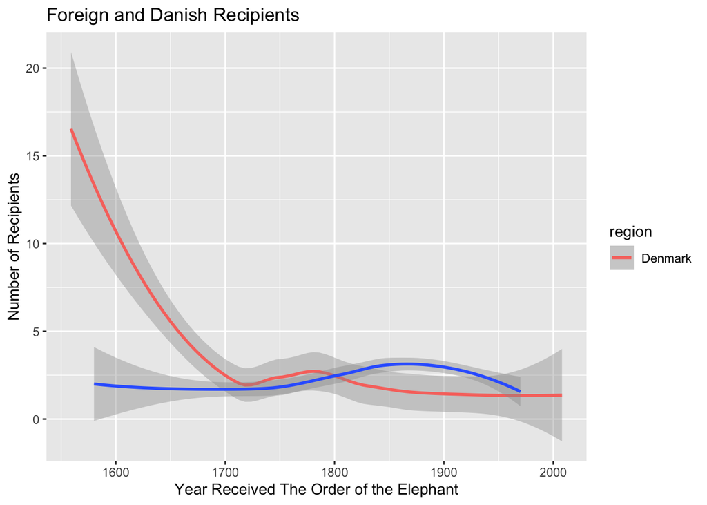

```r
ggplot () +
  geom_smooth(data = elephant_only_denmark, mapping = aes (x = year_received_the_Order_of_the_Elephant, y = n, color = region)) +
  geom_smooth(data = elephant_sum_foreign, mapping = aes(x = year_received_the_Order_of_the_Elephant, y = n)) + ggtitle("Foreign and Danish Recipients") + xlab("Year Received The Order of the Elephant") + ylab("Number of Recipients")
```

# Creating another table this time with continents

```r
elephant_continent <- Elephant_real %>% count (continent, year_received_the_Order_of_the_Elephant, sort = TRUE)
```